# Chemistry of Hazardous Materials: Solids & Radiation

SHM 377 | Hazardous Materials Chemistry | Lecture 04

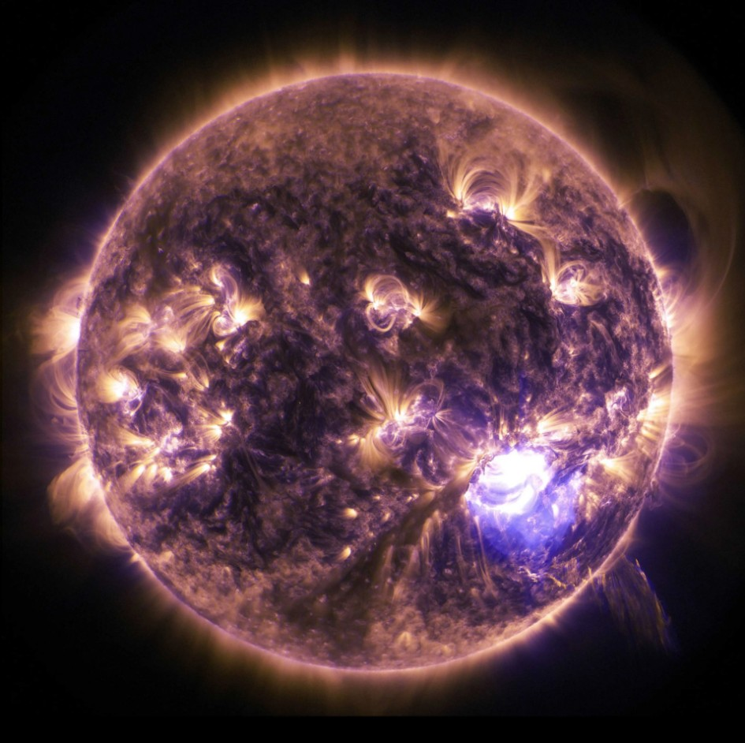

The sun emits a significant solar flare on December 19, 2014, as observed by NASA’s Solar Dynamics Observatory. Source: [TIME (2014)](https://time.com/3644785/space-most-beautiful-photos-2014/). Image credit: SDO/NASA.

## SHM 377: Hazardous Materials Management

### Chemistry of Hazardous Materials: Solids and Radiation

**Lecture 04 · Fall 2026**

Yoni Rodriguez  
Engineering Technologies, Safety, and Construction  
Central Washington University  
Yoni.Rodriguez@cwu.edu

# Introduction: From Atomic Structure to Nuclear Chemistry and Radiation

In Lecture 02, *Chemistry of Hazardous Materials: Matter*, we introduced the fundamental principles of chemistry and explored how scientists use observations and experimental evidence to understand the composition and behavior of matter. We examined how John Dalton developed his atomic theory without being able to observe individual atoms directly, demonstrating how scientific reasoning allows us to explain and predict the behavior of materials.

In Lecture 03, *Chemistry of Hazardous Materials: Solids*, we applied these principles to understand how atomic arrangements, chemical bonding, and the physical and chemical properties of solids influence their behavior and associated hazards.

In this lecture, we will return to the atom and examine how scientists discovered the structure of atoms and their smaller subatomic particles. Through the experimental work of scientists such as J. J. Thomson, Henri Becquerel, Ernest Rutherford, and James Chadwick, we will explore how our understanding of atomic structure developed and how these discoveries contributed to the field of nuclear chemistry.

We will then examine the structure of the atomic nucleus, the differences between isotopes, and the forces that determine nuclear stability. These principles will help us understand why certain nuclei are unstable, how radioactive decay occurs, and why different forms of ionizing radiation are emitted.

Finally, we will apply these chemical principles to hazardous materials management by examining how ionizing radiation interacts with matter, how radiation exposure can affect human health, and how the principles of health physics guide radiation protection and emergency response.

As in our previous chemistry lectures, **our objective is not simply to memorize scientific terminology or equations, but to use scientific evidence to understand hazardous materials, predict their behavior, and make informed decisions that protect workers, the public, and the environment.**

## Learning Objectives

By the end of this lecture, students should be able to:

1. **Explain the development of the atomic model** using experimental evidence from the discovery of subatomic particles, radioactivity, and the atomic nucleus.
2. **Describe atomic and nuclear structure**, including the properties of protons, neutrons, and electrons, and distinguish between atomic number, mass number, and isotopes.
3. **Explain nuclear stability** by examining the strong nuclear interaction, electrostatic repulsion, and the relationship between neutrons and protons.
4. **Describe radioactive decay** and explain how unstable nuclei undergo nuclear transformations, producing daughter nuclei and releasing particles or energy.
5. **Distinguish between the major types of ionizing radiation**, including alpha particles, beta particles, gamma rays, and neutron radiation, based on their origins, physical properties, and interactions with matter.
6. **Interpret fundamental concepts of radioactivity**, including nuclear equations, radioactive decay series, half-life, and activity.
7. **Explain the biological effects of ionizing radiation**, including how energy deposited in biological tissues can cause cellular damage and influence health outcomes.
8. **Apply fundamental radiation protection principles**, including time, distance, shielding, and contamination control, to evaluate radiation hazards and identify appropriate protective measures during hazardous materials incidents.

# Part I. Atoms and the Periodic Table

*Primary source: Chemistry: Atoms First, 2nd ed., Chapter 2*

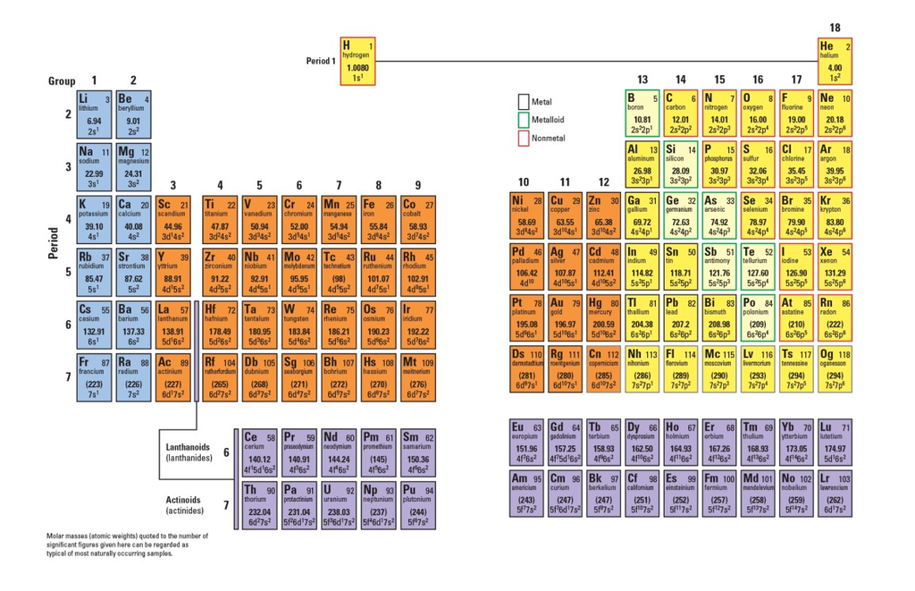

Figure 1: Periodic Table of the Elements.

## 4.1 Atoms First

Let’s review two fundamental concepts from our previous chemistry lectures:

- An **atom** is the smallest unit of an element that retains the chemical properties of that element.
- An **element** is a substance that cannot be broken down into two or more simpler substances by chemical means.

**Examples of elements:**

- **Potassium (K):** Metal
- **Oxygen (O):** Nonmetal
- **Silicon (Si):** Metalloid

### Understanding Atoms: An Analogy

A useful analogy can help us visualize why an atom represents the smallest unit of an element that retains its chemical identity.

Imagine you have a collection of CDs. You can separate the collection into smaller and smaller groups until you are left with a single CD.

You could break that CD into smaller pieces, but would those pieces still be a CD?

**No.** You would have pieces of a CD that no longer function as an individual CD.

Similarly, a collection of atoms can be separated into smaller groups until only one atom remains. Although an atom contains smaller particles, separating those particles would mean it no longer retains the identity of the original element.

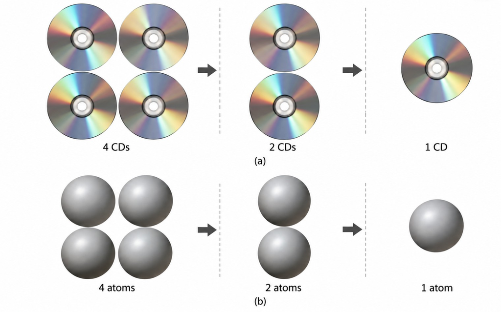

Figure 2: Analogy comparing a collection of CDs with a collection of atoms, illustrating how each can be separated into smaller groups until only one remains.

Remember, John Dalton? Dalton said “that atoms, of which all matter consists, are tiny, indivisible particles.” However, we know that atoms are divisible and made up of smaller subatomic particles.

## 4.2 Subatomic Particles and Atomic Structure

### Discovery of the Electron

In Lecture 02, we discussed how John Dalton proposed that atoms were tiny, indivisible particles. However, scientific discoveries in the late nineteenth century began to challenge this model.

In 1897, the British physicist **J. J. Thomson** investigated the behavior of cathode rays produced when a high voltage was applied between two electrodes inside a vacuum tube.

[figure not shown]

Figure 3: J. J. Thomson and his experimental apparatus.

The rays traveled from the negatively charged electrode, known as the **cathode**, toward the opposite end of the tube, where they could produce a visible glow on a fluorescent screen.

Thomson observed that the rays could be deflected by an electric field. From these observations, he concluded that cathode rays consisted of streams of negatively charged particles, which we now call **electrons**.

Importantly, Thomson found that these particles behaved the same way regardless of the metal used to produce them. This observation led him to conclude that electrons are part of the makeup of all atoms.

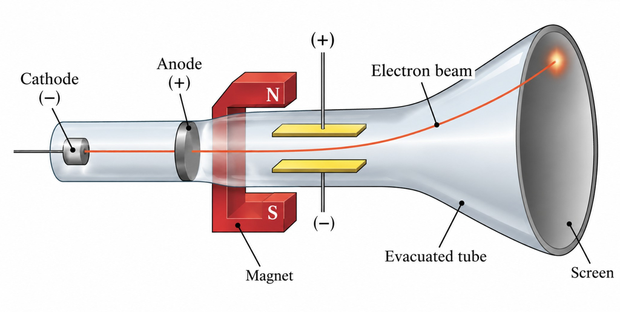

Figure 4: Cathode-ray tube illustrating the deflection of an electron beam by an electric field.

#### Determining the Electron’s Charge and Mass

Thomson’s discovery of the electron was not the result of a single observation. Instead, he conducted a series of experiments to investigate the physical properties of cathode rays.

By applying electric and magnetic fields, Thomson observed that cathode rays could be deflected from their original paths.

When an electric field was applied, the rays were attracted toward the positively charged plate and repelled by the negatively charged plate.

This provided experimental evidence that cathode rays consisted of negatively charged particles.

Thomson’s experiments also demonstrated that these particles were much smaller than atoms, providing further evidence that atoms were not indivisible.

**Scientific significance:** Thomson’s discovery challenged Dalton’s original atomic model and established that atoms contain smaller, negatively charged particles called electrons.

### Millikan’s Oil-Drop Experiment

Following Thomson’s discovery of the electron, scientists understood that atoms contained negatively charged particles. However, they still did not know the magnitude of the electric charge carried by an individual electron.

In the early twentieth century, the American physicist **Robert Millikan**, working with his graduate student **Harvey Fletcher**, developed an ingenious experiment to investigate this question.

Their approach was to study the behavior of extremely small, electrically charged droplets of oil.

#### How the Experiment Worked

Millikan and Fletcher introduced tiny oil droplets into a chamber containing two electrically charged metal plates.

The droplets were affected by two opposing forces:

1. **Gravity:** Pulled the oil droplets downward.
2. **Electric force:** Could push the charged droplets upward or downward, depending on their electric charge and the direction of the electric field.

By adjusting the voltage between the plates, the researchers could change the electric force acting on a droplet.

For some droplets, they could adjust the electric field until the upward electric force balanced the downward pull of gravity.

When these forces were balanced, the droplet remained suspended rather than rising or falling.

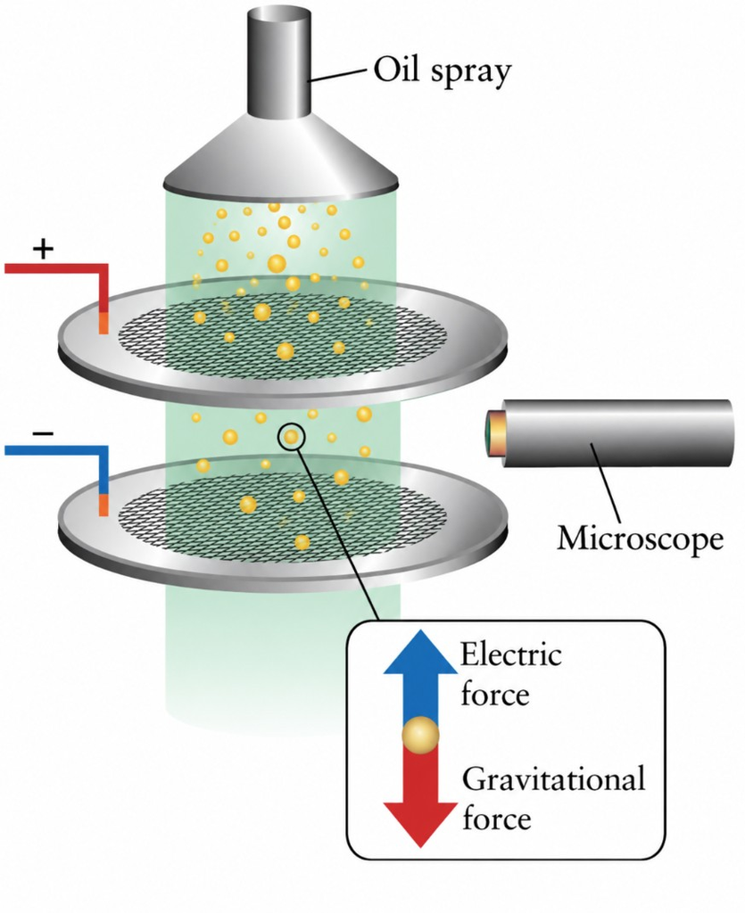

Figure 5: Millikan’s oil-drop experiment, illustrating the apparatus and the opposing electrical and gravitational forces acting on a charged oil droplet.

#### What Did the Researchers Discover?

Millikan and Fletcher found that the charge on any particular drop was always a multiple of $-1.6022 \times 10^{-19}\ \mathrm{C}$, which they deduced was the charge on a single electron.

The notation $10^{-19}$ means **one ten-quintillionth**, or one divided by ten quintillion. The negative sign indicates the electron’s negative electrical charge; the negative exponent indicates how small that charge is. We will define the **coulomb (C)**, the SI unit of electrical charge, in Section 4.6A.

#### Why Was This Discovery Important?

Millikan and Fletcher’s experiments combined with Thomson’s allowed scientists to calculate the mass of an electron:

$$m_e = \frac{\text{Charge}}{\text{Charge/Mass}} = \frac{-1.6022 \times 10^{-19}\ \cancel{\mathrm{C}}}{-1.76 \times 10^{8}\ \cancel{\mathrm{C}}/\mathrm{g}} = 9.10 \times 10^{-28}\ \mathrm{g}$$

In this calculation, $10^{8}$ represents **one hundred million**, while $10^{-28}$ represents **one ten-octillionth**. The calculated electron mass, $9.10 \times 10^{-28}\ \mathrm{g}$, is approximately **9.10 ten-octillionths of a gram**. These extremely small quantities help explain why scientists use scientific notation when describing subatomic particles.

### Radioactivity

While scientists were investigating the electron, other experiments revealed that certain materials could spontaneously emit radiation.

In 1896, French physicist **Henri Becquerel** observed that uranium oxide left in a drawer with photographic plates darkened areas of the plates. From his observations, he realized that uranium must give off some kind of “radiation.” This observation provided evidence that radiation could originate from within matter itself.

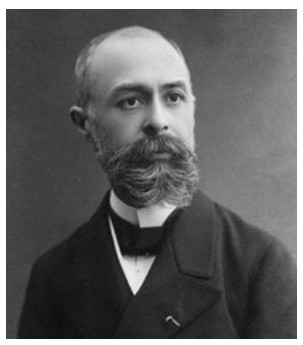

Figure 6: Henri Becquerel and the discovery of radioactivity. Source: University of Washington Environmental Health & Safety, Ionizing Radiation Safety: External Radiation, Philip Campbell, CHP, Radiation Safety Officer, Spring 2022.

[figure not shown]

Figure 7: Photographic plates darkened by radiation emitted from uranium compounds during Henri Becquerel’s experiments.

**Marie Curie** demonstrated that the radiation emitted by uranium, which she called **radioactivity**, was independent of the chemical compound in which the uranium was found. She concluded that the source of this radiation must be the uranium atoms themselves.

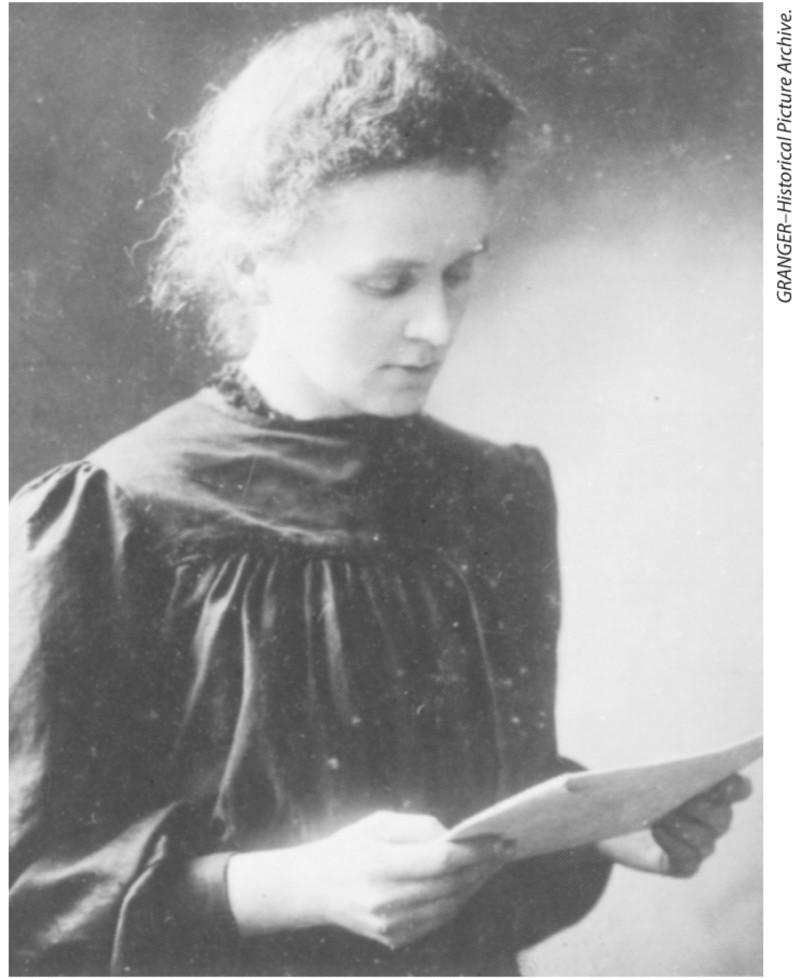

Figure 8: Marie Curie, whose research contributed to the understanding of radioactivity and the discovery of radium and polonium.

Together with her husband, **Pierre Curie**, she received the Nobel Prize in Physics for their research on radiation phenomena. Their investigations also contributed to the discovery of the radioactive elements **polonium** and **radium**, while thorium was also identified as radioactive.

Marie Curie later received a second Nobel Prize, this time in Chemistry, for her discovery of radium and polonium and her research on radium.

**Key definitions:**

- **Radioactivity:** The spontaneous emission of radiation by atomic nuclei.
- **Radioactive:** Having the ability to emit ionizing radiation spontaneously.

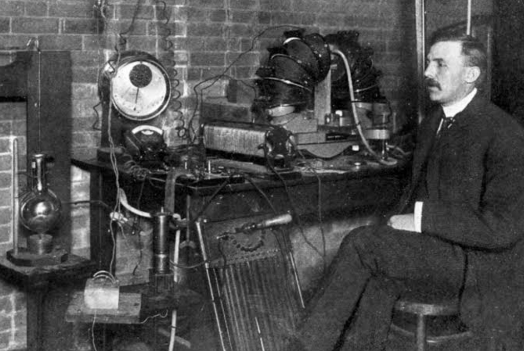

Figure 9: Ernest Rutherford (1871–1937), physicist whose research contributed to the understanding of radioactivity and atomic structure.

*Photograph source: [Rincón Educativo](https://rinconeducativo.org/en/anniversaries/august-30-1871-birth-ernest-rutherford-nobel-prize-considered-one-of-the-fathers-atomic-physics/).*

Radioactivity was a mystery because the structure of the atomic nucleus was still unknown. **Ernest Rutherford** took the first steps in discovering its origin when he identified three different types of electric fields on radioactive emissions:

These emissions include:

- **Alpha particles (**$\alpha$): Positively charged particles.
- **Beta particles (**$\beta$): Charged particles, including electrons emitted from the nucleus during radioactive decay.
- **Gamma rays (**$\gamma$): High-energy electromagnetic radiation that carries no electric charge, emitted by the nuclei.

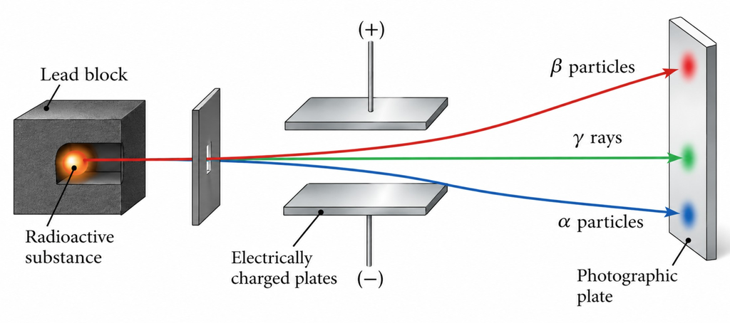

Figure 10: Separation of alpha particles, beta particles, and gamma rays in an electric field.

Because alpha and beta particles carry electric charge, their paths can be deflected by electric or magnetic fields. Gamma rays do not undergo this type of deflection because they have no electric charge.

**What can we learn about an unknown form of radiation by observing how it responds to an electric field?**

These discoveries provided additional evidence that atoms were more complex than Dalton’s original model suggested.

### The Proton and the Nuclear Model of the Atom

Although Thomson demonstrated that atoms contain negatively charged electrons, another question remained:

**If atoms contain negatively charged electrons, why are atoms electrically neutral?**

Scientists reasoned that atoms must also contain positive charge to balance the negative charge of their electrons.

Thomson proposed a plum-pudding model in which negatively charged electrons were embedded within a region of distributed positive charge.

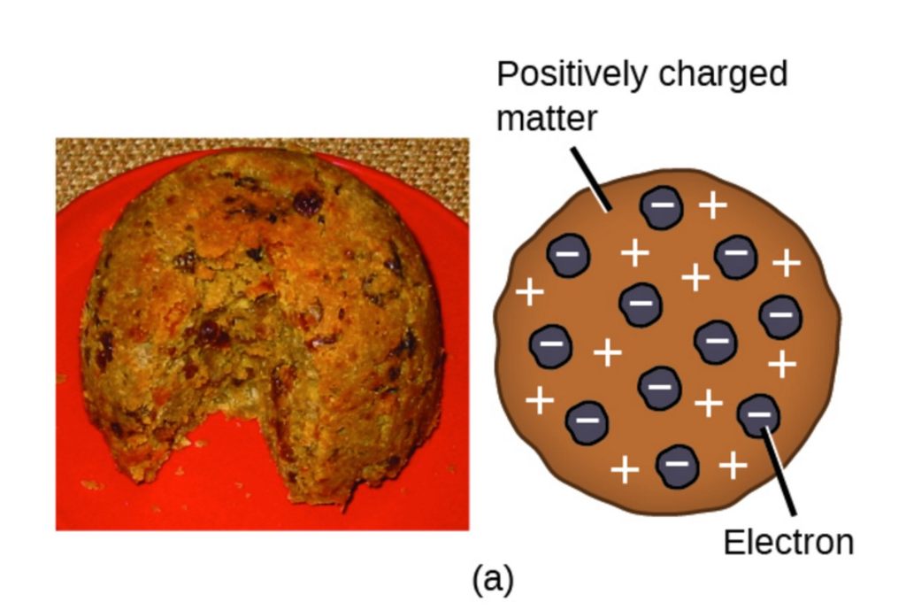

Figure 11: J. J. Thomson’s plum-pudding model of the atom, showing negatively charged electrons embedded within a region of distributed positive charge.

*Image source: [Khan Academy, Discovery of the Electron and Nucleus](https://www.khanacademy.org/science/cambridge-o-level-physics-cie/x0e04e0cb682fb793:nuclear-physics/x0e04e0cb682fb793:the-atom/a/discovery-of-the-electron-and-nucleus).*

However, subsequent experiments challenged this explanation.

#### Rutherford’s Gold Foil Experiment

**Ernest Rutherford**, working with **Hans Geiger and Ernest Marsden**, investigated how positively charged alpha particles interacted with thin metal foil.

The researchers directed alpha particles toward the foil and observed their scattering using a fluorescent screen.

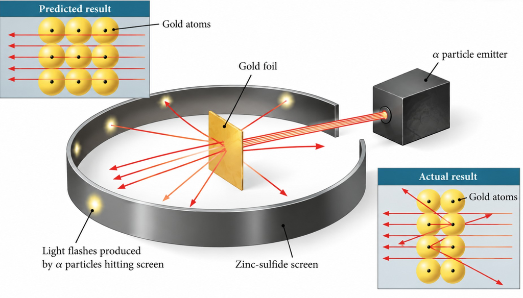

Figure 12: Rutherford’s gold foil experiment illustrating the predicted and observed scattering of alpha particles, including particles passing through the foil, particles experiencing deflection, and particles reversing direction.

They made three important observations:

1. **Most alpha particles passed through the foil** with little or no change in direction.
2. **Some alpha particles were deflected** from their original paths.
3. **A very small number of alpha particles experienced a large repulsive force and therefore a large deflection**, making the alpha particle traveling directly toward the nucleus completely repelled and reverse in direction.

From these observations, Rutherford concluded that most of an atom consists of relatively empty space, while its positive charge and most of its mass are concentrated in a small, dense region called the **atomic nucleus**.

This became known as the **nuclear model of the atom**.

#### From the Nucleus to the Proton

The positive charge of the nucleus is associated with particles called **protons**.

A proton carries a positive electric charge equal in magnitude to the negative charge of an electron.

In an electrically neutral atom, the number of protons equals the number of electrons.

For example, an aluminum atom has an atomic number of 13. This means its nucleus contains 13 protons. A neutral aluminum atom also contains 13 electrons.

**Scientific significance:** Rutherford’s scattering experiment demonstrated that an atom’s positive charge is concentrated in a small nucleus rather than distributed uniformly throughout the atom.

### The Neutron

Although Rutherford’s nuclear model explained the concentration of positive charge within the nucleus, protons and electrons alone could not account for the mass of many atoms.

- It was known that hydrogen, the simplest atom, contained only one proton.
- It was also known that the helium atom contained two protons.
- Therefore, the ratio of the mass of a helium atom to that of a hydrogen atom should be 2:1 (because electrons are much lighter than protons).
- In reality, the mass ratio was approximately 4:1.

This led Rutherford and others to think that there must be another type of subatomic particle in the atomic nucleus.

In 1932, British physicist **James Chadwick** bombarded a thin sheet of beryllium with alpha particles. A very high-energy radiation was emitted by the metal that was not deflected by either electric or magnetic fields, similar to gamma rays. Later experiments showed that the radiation consisted of a third type of subatomic particle, which Chadwick named **neutrons**.

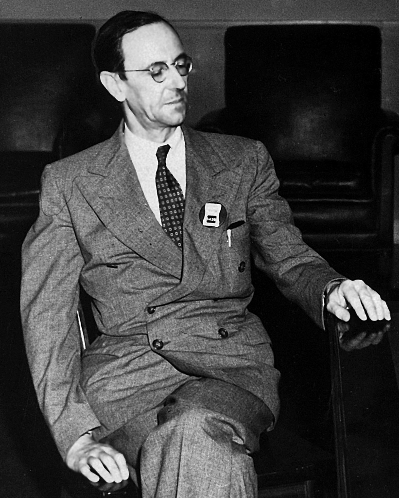

Figure 13: James Chadwick, the British physicist whose experiments in 1932 provided evidence for the existence of the neutron.

*Photograph source: [Wikipedia, James Chadwick](https://en.wikipedia.org/wiki/James_Chadwick).*

The discovery of the neutron helped explain the mass of atomic nuclei.

We now understand that atoms contain three fundamental subatomic particles:

- **Protons:** Positively charged particles that determine the identity of an element.
- **Neutrons:** Electrically neutral particles that contribute to nuclear mass and influence nuclear stability.
- **Electrons:** Negatively charged particles that occupy the region surrounding the nucleus.

The approximate scale of an atom is often expressed as $10^{-10}\ \mathrm{m}$, or **one ten-billionth of a meter**. A nuclear scale of $10^{-14}\ \mathrm{m}$ corresponds to **one hundred-trillionth of a meter**. These values illustrate why the nucleus occupies only a tiny fraction of the atom’s overall size.

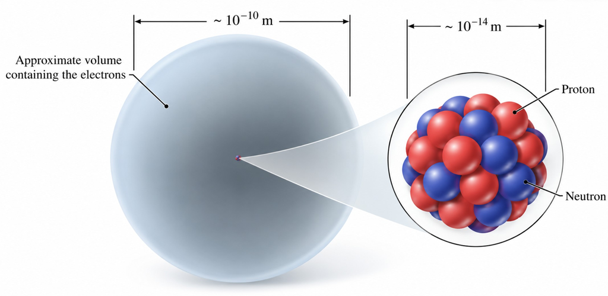

Figure 14: Comparison of atomic and nuclear scales, illustrating the region occupied by electrons and an enlarged nucleus containing protons and neutrons.

[figure not shown]

Figure 15: If the nucleus of an atom were the size of a fly at the center of a baseball field, then the space occupied by the surrounding electrons would be about the size of the entire stadium

*Photograph source: [Wikipedia, Dodger Stadium](https://en.wikipedia.org/wiki/Dodger_Stadium).*

**Scientific significance:** Chadwick’s discovery helped establish our modern understanding of the nucleus as a structure containing both protons and neutrons.

### Historical Development of Atomic Structure and Radioactivity

Our understanding of atomic structure developed through a series of scientific discoveries. Each discovery provided new experimental evidence that challenged earlier explanations of matter and helped scientists develop a more complete understanding of the atom.

1. **John Dalton (Early 1800s): Atomic Theory**

   Dalton proposed that matter consists of tiny, indivisible particles called atoms. His atomic theory provided a foundation for explaining the composition and behavior of matter.
2. **Henri Becquerel (1896): Discovery of Radioactivity**

   Becquerel observed that uranium-containing materials could darken photographic plates without exposure to light. His observations provided evidence that radiation could originate from within matter itself.
3. **J. J. Thomson (1897): Discovery of the Electron**

   Thomson investigated cathode rays and demonstrated that they consisted of negatively charged particles called electrons. His experiments provided evidence that atoms contain smaller subatomic particles and are not indivisible.
4. **Marie and Pierre Curie (1898 onward): Investigations of Radioactivity**

   Marie Curie demonstrated that radioactivity was associated with atoms rather than their chemical compounds. Together, Marie and Pierre Curie investigated radioactive materials and contributed to the discovery of polonium and radium.
5. **Robert Millikan and Harvey Fletcher (Early 1900s): Measurement of the Electron’s Charge**

   Through their oil-drop experiments, Millikan and Fletcher determined the magnitude of the elementary electric charge. Combined with Thomson’s measurements, their findings allowed scientists to calculate the mass of an electron.
6. **Ernest Rutherford (1911): Discovery of the Atomic Nucleus**

   Rutherford, working with Hans Geiger and Ernest Marsden, investigated the scattering of alpha particles through thin metal foil. Their observations provided evidence that most of an atom consists of relatively empty space, with its positive charge and most of its mass concentrated in a small, dense nucleus.
7. **James Chadwick (1932): Discovery of the Neutron**

   Chadwick investigated radiation produced when beryllium was bombarded with alpha particles. His experiments provided evidence for the existence of electrically neutral particles called neutrons, helping explain the mass and composition of atomic nuclei.

**Scientific significance:** These discoveries demonstrate how scientific understanding develops through observations, experimentation, and the evaluation of evidence. Scientists were able to investigate the structure of atoms and identify subatomic particles even though they could not directly observe individual atoms.

Together, these discoveries established the foundation for our modern understanding of atomic structure, radioactivity, and nuclear chemistry.

## 4.3 Atomic Number, Mass Number, and Isotopes

All elements on the periodic table can be identified by the following:

- The **atomic number (**$Z$): the number of protons in the nucleus of each atom of an element.
- The **mass number (**$A$): the total number of neutrons *AND* protons. Often referred to *jointly* as **nucleons**.

Therefore:

$$\text{Mass number } (A) = \text{Number of protons } (Z) + \text{Number of neutrons}$$

or

$$\text{Number of neutrons} = \text{Mass number } (A) - \text{Number of protons } (Z)$$

or

$$\text{Number of protons (Z)} = \text{Mass number } (A) - \text{Number of neutrons}$$

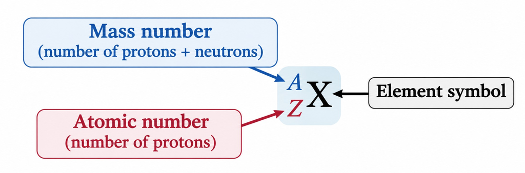

Figure 16: Nuclear notation illustrating the atomic number, mass number, and chemical element symbol.

What do we call an atom that has the same atomic number (Z) but different mass numbers (A)?

### Isotopes

Most elements have two or more isotopes, atoms that have the same atomic number (same number of protons *and* electrons) but different number of neutrons.

How do we identify an isotope from an element?

- We write the mass number after the name of the element. Take Uranium for example:

[figure not shown]

Figure 17: Comparison of uranium-238 and uranium-235, illustrating two isotopes of uranium with the same atomic number but different mass numbers.

The isotope Uranium-235 (U-235) has 143 neutrons in its nucleus (235-92 = 143) and is used in nuclear reactors and atomic bombs, whereas U-238 does not behave the same way in these applications.

NOTE: the chemical properties of an element are determined primarily by the number of protons and electrons in its atoms; not by the number of neutrons. Therefore, isotopes of the same element usually, not always, exhibit very similar chemical properties.

## 4.4 Nuclear Stability

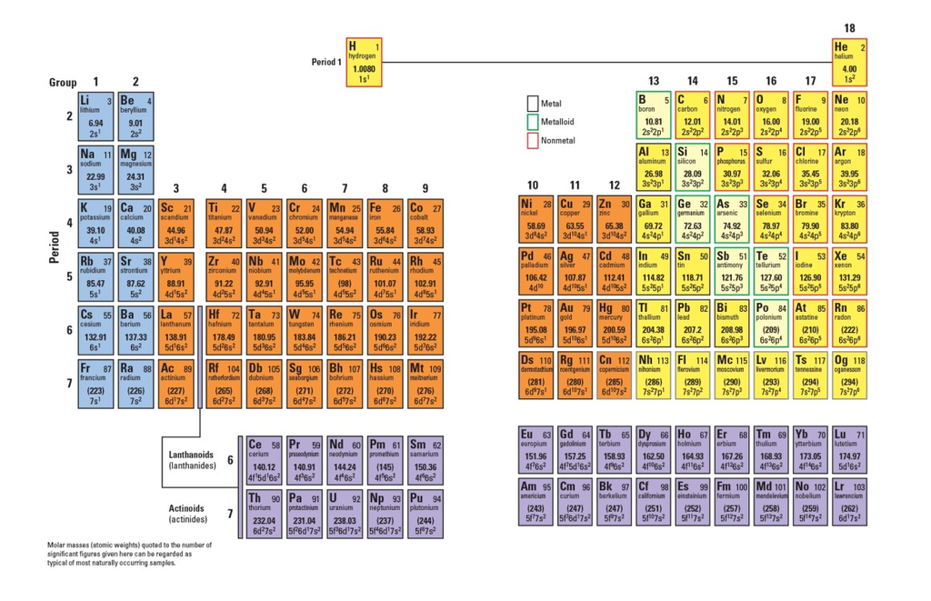

Periodic Table of the Elements.

The nuclei of some elements are stable, but others decay seconds after they are formed. Therefore, patterns of stability and instability of nuclei are useful to make predictions regarding nuclear decay.

The principal factor that determines whether a nucleus is stable is the *neutron-to-proton ratio (n/p)*. For atoms of elements having low atomic numbers (less than or equal to 20; calcium), the *n/p* value is close to 1. The increase in the ratio of neutrons-to-protons with increasing atomic number can be explained by considering the role of the neutrons in helping to overcome the electrical repulsion between protons. The strong force that holds protons and neutrons together in a nucleus is powerful enough to overcome the electrostatic repulsion between the protons, but it can act over only a very short distance, about the diameter of a nucleus.

Given that neutrons are uncharged, they can contribute to the strong force without adding to the electrostatic repulsion. Therefore, a lot of neutrons are needed to overcome the mutal repulsion of the protons in a nucleus of high atomic number, which explains why the band of stability curves upward.

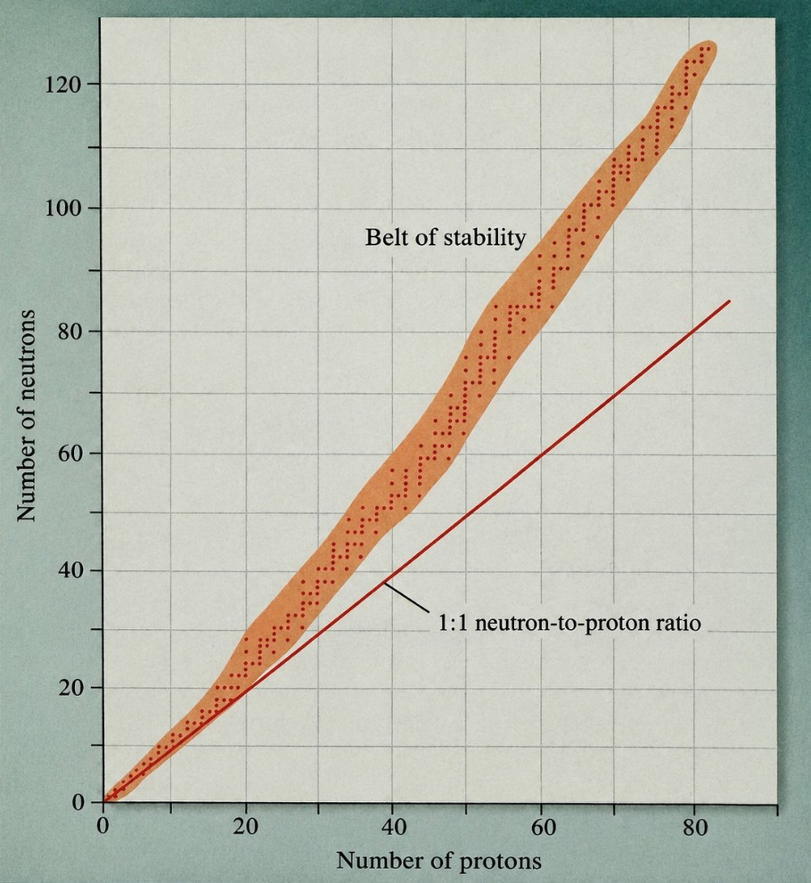

Figure 18: Belt of nuclear stability showing how the neutron-to-proton ratio increases with atomic number.

*Figure adapted from Figure 2.9, “Plot of Neutrons Versus Protons,” Chapter 2: Atoms and the Periodic Table, in Chemistry: Atoms First by Julia Burdge and Jason Overby.*

General patterns:

- **magic numbers** there are more stable nuclei containing *2, 8, 20, 50, 82, and 126* protons or neutrons than there are containing other numbers of protons or neutrons.
  - Example: tin (Sn) vs. antimony (Sb):

  | Element | atomic number | stable isotopes |
  | --- | --- | --- |
  | Tin (Sn) | 50 | 10 |
  | Antimony (Sb) | 51 | 2 |

- There are more stable nuclei with even numbers of both protons and neutrons than with odd numbers of these particles.
- All isotopes of the elements with atomic numbers higher than 82 are radioactive.
  - NOTE: Bismuth Z = 83 was long thought to have a stable isotope but it was found to decay very slowly.
- All isotopes of technetium (Tc, Z = 43) and promethium (Pm, Z = 61) are radioactive.

# Part II. Nuclear Chemistry

*Primary source: Chemistry: Atoms First, 2nd ed., Chemical Principles Focus 9: Nuclear Chemistry.*

## 4.4 Nuclei and Nuclear Reactions

### Nuclei

Rutherford showed that each type of radiation is produced by **nuclear decay**. A change in the composition of a nucleus is called a **nuclear reaction**.

A specific atom with a given atomic number (Z) and mass number (A) is called a **nuclide**. For example, ${}^{1}_{1}\mathrm{H}$, ${}^{2}_{1}\mathrm{H}$, and ${}^{16}_{8}\mathrm{O}$ are three different nuclides, with the first two being isotopes of the same element.

Nuclei that change their *structure spontaneously* and *emit radiation* are described as **radioactive**. Often, the result is a nucleus of a different element.

### Understanding the Nuclear Notation

Nuclear notation identifies an element and its atomic number and mass number.

$${}^{A}_{Z}\mathrm{X}$$

- **A (upper left):** Mass number, the total number of protons and neutrons.
- **Z (lower left):** Atomic number, the number of protons.
- **X (right):** Chemical symbol of the element.

**For hydrogen-1:**

$${}^{1}_{1}\mathrm{H}$$

- Mass number = 1
- Atomic number = 1
- Number of protons = 1
- Number of neutrons = 1 − 1 = 0

### Understanding Nuclear Reactions

Nuclear reactions differ in some important ways from chemical reactions.

1. Different isotopes of the same element undergo essentially the same chemical reactions but undergo very different nuclear reactions.
2. Some nuclear reactions, such as those in which $\alpha$ or $\beta$ particles are emitted from the nucleus, leave behind a nucleus with a different number of protons and which is therefore the nucleus of an atom of a different element. The product nucleus is called a **daughter nucleus.**

For example, when atmospheric ${}^{14}_{7}\mathrm{N}$ is converted to ${}^{14}_{6}\mathrm{C}$ and ${}^{1}_{1}\mathrm{H}$, **nuclear transmutation** has taken place. This transformation occurs when nitrogen-14 is bombarded by neutrons produced through cosmic-ray interactions in the atmosphere.

$${}^{14}_{7}\mathrm{N}
+
{}^{1}_{0}\mathrm{n}
\;\longrightarrow\;
{}^{14}_{6}\mathrm{C}
+
{}^{1}_{1}\mathrm{H}$$

This type of transmutation occurs naturally, but nuclear transmutation can also be achieved artificially.

3. Another important difference between nuclear and chemical reactions is that energy changes are very much greater for nuclear reactions than for chemical reactions.

   For example, the combustion of $1.0\ \mathrm{g}$ of methane produces about $52\ \mathrm{kJ}$ of energy as heat. In contrast, a nuclear reaction of $1.0\ \mathrm{g}$ of uranium-235 produces about $8.2 \times 10^{7}\ \mathrm{kJ}$ of energy, more than a million times as much.

   The notation $10^{7}$ represents **ten million**. Therefore, $8.2 \times 10^{7}\ \mathrm{kJ}$ is equivalent to approximately **82 million kilojoules**. A kilojoule (kJ) is one thousand joules (J), a unit of energy.

   To put that energy into perspective:
   - **A moving baseball:** A 250-gram baseball thrown or hit at roughly 20 meters per second (45 mph) carries about 50 joules of kinetic energy.
   - **Walking/Climbing:** Walking up a flight of stairs (roughly 10 to 12 steps) uses around 2 to 4 kilojoules depending on your body weight.

Comparison of Chemical Reactions and Nuclear Reactions

| Chemical Reactions | Nuclear Reactions |
| --- | --- |
| 1. Atoms are rearranged by the breaking and forming of chemical bonds. | 1. Elements are converted to other elements (or isotopes). |
| 2. Only electrons in atomic or molecular orbitals are involved in the reaction. | 2. Protons, neutrons, electrons, and other subatomic particles such as $\alpha$ particles may be involved. |
| 3. Reactions are accompanied by the absorption or release of relatively small amounts of energy. | 3. Reactions are accompanied by the absorption or release of tremendous amounts of energy. |
| 4. Rates of reaction are influenced by temperature, pressure, concentration, and catalysts. | 4. Rates of reaction normally are not affected by temperature, pressure, or catalysts. |

*Source: Burdge, J., & Overby, J. (2018). Chemistry: Atoms First (2nd ed.), Chapter 20, Table 20.1, “Comparison of Chemical Reactions and Nuclear Reactions.”*

### Key Definitions

- **nuclear decay:** the partial breakup of a nucleus
- **nuclear reaction:** a change that a nucleus undergoes
- **nuclide:** An atom of specified atomic number and mass number. *Examples* ${}^{1}_{1}\mathrm{H}$, ${}^{16}_{8}\mathrm{O}$
- **radioactive:** A nucleus is radioactive if it can change its structure spontaneously and emit radiation.
- **daughter nucleus:** a nucleus that is the produce of a nuclear decay.
- **nuclear transmutation:** The conversion of one element into another.

# Types of Nuclear Radiation

Rutherford identified three common types of nuclear radiation: alpha ($\alpha$) particles, beta ($\beta$) particles, and gamma ($\gamma$) rays. Each differs in its physical characteristics, electric charge, and degree of penetration.

#### Alpha Particles ($\alpha$)

**Alpha-particle radiation:** ${}^{4}_{2}\alpha$ is positively charged and can be thought of as a tightly bound cluster of two protons and two neutrons. An alpha particle is also often referred to as a helium nucleus: ${}^{4}_{2}\mathrm{He}$.

When a nucleus emits an alpha particle, its **atomic number decreases by two** and its **mass number decreases by four.**

We can represent this transformation using a **nuclear equation**, which shows how an unstable nucleus changes into a different nucleus while emitting radiation.

For example, when polonium-212 undergoes alpha decay:

$${}^{212}_{84}\mathrm{Po}
\;\longrightarrow\;
{}^{4}_{2}\alpha
\;+\;
{}^{208}_{82}\mathrm{Pb}$$

In this nuclear equation:

- **Parent nucleus:** Polonium-212 (${}^{212}_{84}\mathrm{Po}$)
- **Emitted particle:** Alpha particle (${}^{4}_{2}\alpha$)
- **Daughter nucleus:** Lead-208 (${}^{208}_{82}\mathrm{Pb}$)

The atomic number decreases from 84 to 82, while the mass number decreases from 212 to 208.

**Degree of penetration:** Alpha particles have very limited penetration. They can travel only a short distance through air (*~4 inches from their source*) and can be stopped by a sheet of paper or the outer layer of skin.

Although alpha particles generally present a limited external radiation hazard, radioactive material that emits alpha particles can be particularly damaging if it enters the body through inhalation, ingestion, or wounds.

*Source: Bevelacqua, A. S., & Norman, L. A. Hazardous Materials Chemistry (3rd ed.). Jones & Bartlett Learning, Chapter 3, “Alpha Particles.”*

#### Beta Particles ($\beta$)

**Beta-particle radiation:** ${}^{0}_{-1}\beta$ is negatively charged, and by measuring the charge and mass of these particles, Rutherford showed that they are electrons. Given that a beta particle has no protons or neutrons, its mass number is 0 and can be written as ${}^{0}_{-1}\mathrm{e}$.

Beta particles are high-speed electrons emitted during nuclear transformations.

During negative beta decay ($\beta^{-}$), **a neutron** in the nucleus is **converted into a proton**, and an **electron is emitted**. **The atomic number increases by one**, while **the mass number remains unchanged**.

We can represent this transformation using the following nuclear equation:

$${}^{1}_{0}\mathrm{n}
\;\longrightarrow\;
{}^{1}_{1}\mathrm{p}
\;+\;
{}^{0}_{-1}\mathrm{e}$$

We can represent this transformation using a **nuclear equation**, which shows how an unstable nucleus changes into a different nucleus while emitting radiation.

For example, when strontium-90 undergoes beta-minus decay:

$${}^{90}_{38}\mathrm{Sr}
\;\longrightarrow\;
{}^{0}_{-1}\beta
\;+\;
{}^{90}_{39}\mathrm{Y}$$

In this nuclear equation:

- **Parent nucleus:** Strontium-90 (${}^{90}_{38}\mathrm{Sr}$)
- **Emitted particle:** Beta particle (${}^{0}_{-1}\beta$)
- **Daughter nucleus:** Yttrium-90 (${}^{90}_{39}\mathrm{Y}$)

The atomic number increases from 38 to 39, while the mass number remains 90.

**Degree of penetration:** Beta particles are moderately penetrating. They generally travel farther through air than alpha particles (*~1 to 20 feet from their source*) and can penetrate the outer layers of skin.

Beta radiation can be shielded using suitable materials, including plastic or thin sheets of metal. The choice of shielding material depends on the energy of the beta particles.

*Source: Bevelacqua, A. S., & Norman, L. A. Hazardous Materials Chemistry (3rd ed.). Jones & Bartlett Learning, Chapter 3, “Beta Particles.”*

#### Gamma Radiation ($\gamma$)

**Gamma radiation:** The third common type of nuclear radiation is gamma radiation, represented by the Greek letter $\gamma$. Gamma rays were first identified by Paul Villard in 1900 and were subsequently studied and named by Ernest Rutherford.

Like visible light, gamma radiation is a form of electromagnetic radiation, but gamma rays emitted during nuclear transitions generally have much higher frequencies and photon energies.

Gamma rays can be emitted when an excited nucleus moves from a higher-energy state to a lower-energy state. Unlike alpha or beta decay, **gamma emission by itself does not change the atomic number or mass number of the nucleus.**

We can represent this transformation using a **nuclear equation**, which shows how an excited nucleus releases energy in the form of a gamma-ray photon.

##### Example: Technetium-99m in Nuclear Medicine

Technetium-99m is a radioactive nuclear isomer of technetium-99 commonly used in nuclear medicine for diagnostic imaging.

The superscript **m** in technetium-99m (${}^{99m}_{43}\mathrm{Tc}$) stands for **metastable**, indicating that the nucleus is in an **excited nuclear state**. This means that the nucleus contains more energy than the same nucleus in its **ground state**, or lowest-energy state.

In this example:

- **Technetium (Tc):** The chemical element.
- **Atomic number (43):** The nucleus contains 43 protons.
- **Mass number (99):** The nucleus contains 99 protons and neutrons combined.
- **Metastable (m):** The nucleus is in an excited nuclear state.

The gamma emission from technetium-99m can be represented by the following simplified nuclear equation:

$${}^{99m}_{43}\mathrm{Tc}
\;\longrightarrow\;
{}^{99}_{43}\mathrm{Tc}
\;+\;
{}^{0}_{0}\gamma$$

In this nuclear equation:

- **Parent nucleus:** Technetium-99m (${}^{99m}_{43}\mathrm{Tc}$), in an excited nuclear state.
- **Emitted radiation:** Gamma-ray photon (${}^{0}_{0}\gamma$), which carries away energy.
- **Resulting nucleus:** Technetium-99 (${}^{99}_{43}\mathrm{Tc}$), in its nuclear ground state.

Notice that the **atomic number remains 43** and the **mass number remains 99**. Only the energy state of the nucleus changes.

This process is called an **isomeric transition** because the nucleus releases energy without changing its number of protons or neutrons.

Although technetium-99 is in its nuclear ground state, it is still radioactive and undergoes further radioactive decay over a much longer period.

**Application in nuclear medicine:** Technetium-99m is a valuable diagnostic tool because gamma radiation emitted from radioactive material inside the body can be detected using specialized imaging equipment.

Patients may receive a radiopharmaceutical containing technetium-99m by injection or, for certain examinations, by ingestion. By detecting the emitted gamma radiation, medical professionals can obtain diagnostic images that help evaluate organs such as the **heart, liver, and lungs**.

*Source: Burdge, J., & Overby, J. Chemistry: Atoms First (2nd ed.), Chapter 20, Nuclear Chemistry.*

### Additional Nuclear Transformations and Radiation Types

#### Electron Capture: Iodine-125

In **electron capture**, an electron from an atomic orbital is captured by the nucleus, and a proton is converted into a neutron. The **atomic number decreases by one**, while the **mass number remains unchanged**.

$${}^{1}_{1}\mathrm{p}+{}^{0}_{-1}\mathrm{e}\longrightarrow{}^{1}_{0}\mathrm{n}+\nu_e$$

For example, iodine-125 undergoes electron capture to produce tellurium-125:

$${}^{125}_{53}\mathrm{I}+{}^{0}_{-1}\mathrm{e}\longrightarrow{}^{125}_{52}\mathrm{Te}^{*}+\nu_e$$

The daughter atom can subsequently release energy as it relaxes, including characteristic X-rays and Auger electrons; nuclear gamma emission can also occur from an excited nuclear state. The asterisk indicates an excited state, and $\nu_e$ denotes an electron neutrino. The **change from atomic number 53 to 52 is caused by electron capture**, not by subsequent photon emission.

*Source: Bevelacqua, A. S., & Norman, L. A. Hazardous Materials Chemistry (3rd ed.), Chapter 3, “Gamma Radiation.”*

#### Other Nuclear Particles and Processes

Nuclear processes may also involve protons, neutrons, and **positrons**. A proton is a hydrogen-1 nucleus (${}^{1}_{1}\mathrm{p}$); a neutron is represented by ${}^{1}_{0}\mathrm{n}$.

A **positron** ($\beta^{+}$ or ${}^{0}_{+1}\mathrm{e}$) is the electron’s antiparticle: it has the same mass as an electron but a positive electric charge. When a positron encounters an electron, they can annihilate and produce photons. Positron emission, like electron capture, converts a proton into a neutron in the nucleus.

#### Comparison of Nuclear Radiation

Comparison of Common Types of Nuclear Radiation

| Radiation or particle | Representation | Charge | General penetration behavior |
| --- | --- | --- | --- |
| Alpha particle | ${}^{4}_{2}\alpha$ | +2 | Low; stopped by paper or outer skin |
| Beta particle | ${}^{0}_{-1}\mathrm{e}$ | −1 | Moderate; can affect skin |
| Gamma photon | $\gamma$ | 0 | Highly penetrating; attenuated by dense shielding |
| Positron | ${}^{0}_{+1}\mathrm{e}$ | +1 | Charged-particle range depends on energy; annihilation photons can penetrate |
| Proton | ${}^{1}_{1}\mathrm{p}$ | +1 | Strongly dependent on energy |
| Neutron | ${}^{1}_{0}\mathrm{n}$ | 0 | Can be highly penetrating; depends on energy and material |

*Source: Adapted from Atkins, Jones, Laverman, Patterson, and Young, Chemical Principles (8th ed.), Focus 9: Nuclear Chemistry, Table 9A.1.*

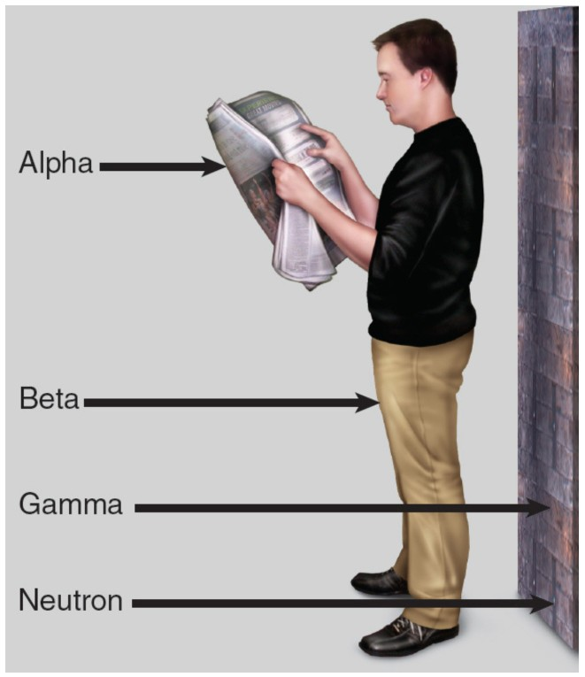

Figure 19: Penetrating potential of different types of nuclear radiation.

The table describes general tendencies, not universal stopping distances. Radiation energy and shielding thickness matter. Gamma radiation often accompanies other nuclear transformations and can penetrate deeply into matter; lead or sufficiently thick concrete can reduce its intensity.

### Returning to Nuclear Stability

Earlier, we introduced the **neutron-to-proton ratio** and the **belt of nuclear stability**. We can now ask: **Why do different unstable nuclei emit different types of radiation?**

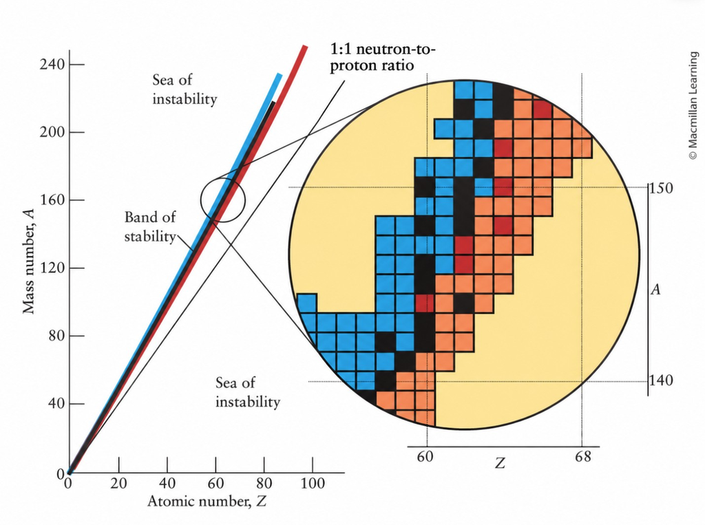

Figure 20: Band of nuclear stability showing the relationship between atomic number and mass number.

#### Predicting Common Nuclear Transformations

**Note:** These are **general patterns**, not rules that uniquely predict the decay of every isotope. Nuclear energy levels and other factors determine which transformations are possible.

- Nuclides along the narrow black band (the band of stability) are generally stable.
- Nuclides in the blue region (to the left) are likely to emit a ${}^{0}_{-1}\beta$ particle.
- Nuclides in the red region (to the right) are likely to emit positrons or undergo electron capture.
- The straight diagonal line indicates the position that nuclides would have if the numbers of neutrons and protons were equal.
- Nuclei that do not lie within the belt of stability, as well as nuclei with more than 82 protons, tend to be unstable.

The spontaneous emission of particles or electromagnetic radiation by unstable nuclei is known as **radioactivity**.

The main nuclear transformations we have examined include the emission of alpha ($\alpha$) particles, beta ($\beta$) particles, and gamma ($\gamma$) rays, as well as positron ($\beta^{+}$) emission and electron capture.

The disintegration of a radioactive nucleus is often the beginning of a **radioactive decay series**.

#### Natural Radioactivity: The Uranium-238 Decay Series

Some radioactive nuclei undergo a series of nuclear transformations before reaching a stable state.

The uranium-238 decay series illustrates how a radioactive parent nucleus can produce several radioactive daughter nuclei through successive emissions of alpha ($\alpha$) and beta ($\beta$) radiation.

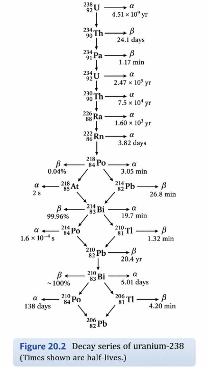

Figure 21: Decay series of uranium-238 showing successive nuclear transformations and the half-lives of radioactive nuclides.

*Source: Burdge, J., & Overby, J. Chemistry: Atoms First (2nd ed.), Chapter 20, Section 20.3, “Natural Radioactivity,” Figure 20.2, p. 881.*

# The Mathematics of Radioactive Decay

#### Applying Exponential and Logarithmic Functions to Radioactive Decay

Before calculating how the amount of radioactive material changes with time, we will review three related mathematical ideas: **linear functions**, **exponential functions**, and **logarithmic functions**. These are different mathematical relationships, and recognizing their differences will help us select an appropriate model for radioactive decay.

Our mathematical review follows the progression in Stewart, Redlin, and Watson, *Precalculus: Mathematics for Calculus*, 6th ed., Chapter 4. We will begin with familiar graphs and equations before applying the mathematics to radioactive material.

##### Reviewing Linear Functions

A **function** describes a relationship between an input and an output. In a graph, we typically place the input, $x$, on the horizontal axis and the output, $y$, on the vertical axis.

A linear function has the form:

$$f(x)=mx+b$$

where:

- $f(x)$ is the output for a given input $x$.
- $x$ is the input variable.
- $m$ is the **slope**, which tells us how much the output changes for each one-unit increase in $x$.
- $b$ is the **vertical intercept**, the value of the function when $x=0$.

A linear function produces a straight line. When $m=0$, the line is horizontal; when $m$ is positive, the line rises; and when $m$ is negative, the line falls as $x$ increases.

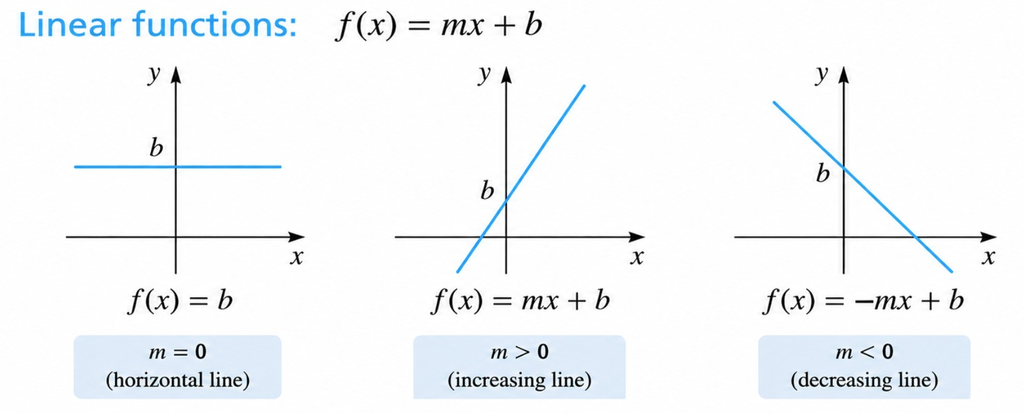

Figure 22: A constant function, $f(x)=b$, and a straight-line function, $f(x)=mx+b$, showing the slope and vertical intercept. Source: Stewart, Redlin, and Watson, *Precalculus: Mathematics for Calculus*, 6th ed.

**How do we calculate the slope of a line?** If we know two points, $P_1(x_1,y_1)$ and $P_2(x_2,y_2)$, then:

$$m=\frac{y_2-y_1}{x_2-x_1}$$

The numerator is the change in the output; the denominator is the change in the input. The point-slope and slope-intercept equations provide two ways to describe the same straight-line relationship.

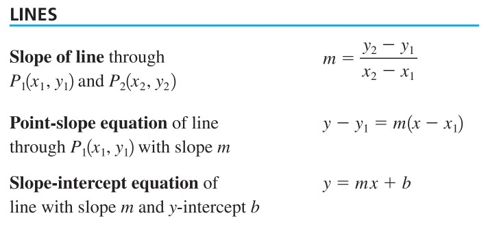

Figure 23: The slope, point-slope, and slope-intercept formulas for straight lines. Source: Stewart, Redlin, and Watson, *Precalculus: Mathematics for Calculus*, 6th ed.

For example, consider:

$$f(x)=300-10x$$

Here, the initial output is 300 and the slope is $-10$. Each time $x$ increases by 1, the output decreases by **10 units**. This is a constant *amount* of decrease, not a constant fraction.

##### Comparing Linear, Exponential, and Logarithmic Graphs

The next figure compares exponential and logarithmic functions. For now, focus on the **top two graphs**: exponential growth curves upward when the base is greater than 1, while exponential decay curves downward when the base lies between 0 and 1. We will return to the bottom two logarithmic graphs after defining logarithms.

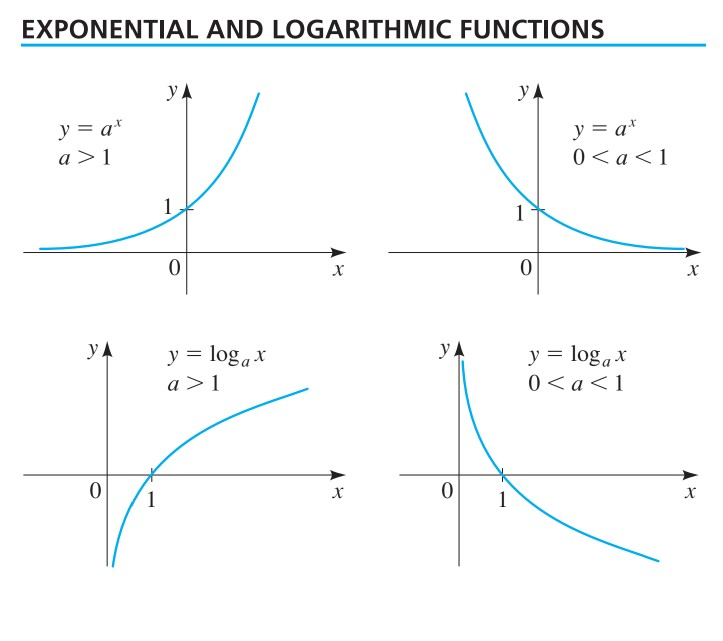

Figure 24: Four graphs comparing exponential growth, exponential decay, and their logarithmic counterparts. Source: Stewart, Redlin, and Watson, *Precalculus: Mathematics for Calculus*, 6th ed.

A straight line changes by the same **amount** over equal input intervals. An exponential function changes by the same **multiplicative factor** over equal input intervals. Radioactive decay follows the second pattern: the fraction remaining after each half-life is constant, even though the amount that decays becomes smaller.

##### Defining Exponential Functions

Stewart defines an exponential function as:

$$\boxed{f(x)=a^x}$$

where:

- $f(x)$ is the output.
- $a$ is the **base**, a fixed positive number other than 1.
- $x$ is the **exponent**, the input variable.

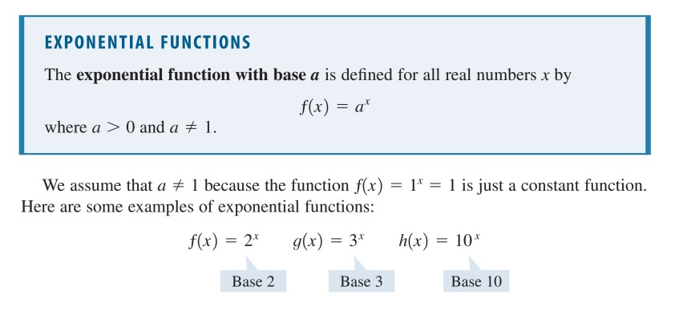

Figure 25: Stewart’s definition of an exponential function, including examples with bases 2, 3, and 10. Source: Stewart, Redlin, and Watson, *Precalculus: Mathematics for Calculus*, 6th ed.

For example, $f(x)=2^x$. If $x=3$, then:

$$f(3)=2^3=2\times2\times2=8$$

When the exponent is a positive whole number, it tells us how many times the base is multiplied by itself. Exponents can also be zero, negative, or fractional:

$$2^0=1,\qquad 2^{-1}=\frac12,\qquad 2^{-2}=\frac14$$

A **negative exponent** means taking a reciprocal: $2^{-2}=1/2^2=1/4$. This is not the same as placing a negative sign in front of the entire function.

##### Graphing Exponential Functions

Consider the two functions shown in Stewart’s worked graphing example:

$$f(x)=3^x$$

$$g(x)=\left(\frac13\right)^x$$

The first function has a base greater than 1 and increases as $x$ increases. The second has a base between 0 and 1 and decreases as $x$ increases.

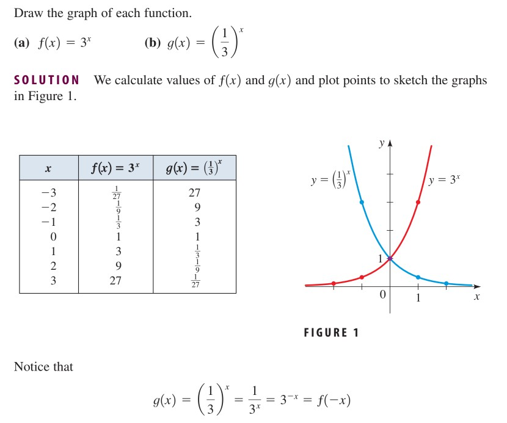

Figure 26: Table of values and graphs comparing $f(x)=3^x$ with $g(x)=(1/3)^x$. Source: Stewart, Redlin, and Watson, *Precalculus: Mathematics for Calculus*, 6th ed., Section 4.1.

Notice that both functions equal 1 when $x=0$. However, when $x=1$, the first function equals 3 and the second equals $1/3$. **A base between 0 and 1 produces exponential decay.**

##### Comparing a Family of Exponential Functions

The next figure shows several exponential functions together. Every curve passes through $(0,1)$ because $a^0=1$ for any allowed base $a$.

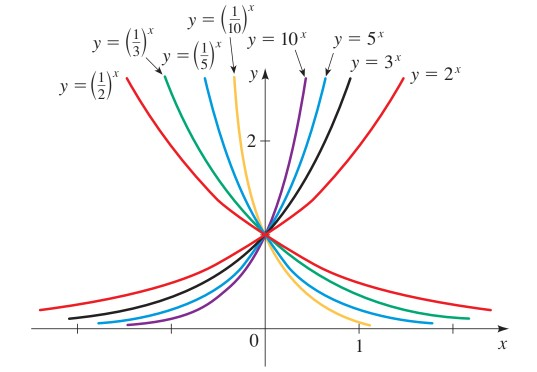

Figure 27: Family of exponential functions with bases greater than 1 and between 0 and 1, including $(1/2)^x$. Source: Stewart, Redlin, and Watson, *Precalculus: Mathematics for Calculus*, 6th ed.

The curve $y=(1/2)^x$ is particularly relevant to our later discussion of radioactive half-life. For each increase of 1 in $x$, the output is multiplied by $1/2$:

$$\begin{aligned}
x=0 &: \quad (1/2)^0=1\\
x=1 &: \quad (1/2)^1=1/2\\
x=2 &: \quad (1/2)^2=1/4\\
x=3 &: \quad (1/2)^3=1/8
\end{aligned}$$

We have not yet defined the time variable for radioactive decay. At this stage, $x$ is simply the input. Later, we will show how an exponent can represent the **number of elapsed half-lives**.

##### Distinguishing a Negative Sign from a Negative Exponent

Stewart also illustrates what happens when a negative sign is placed **outside** an exponential expression.

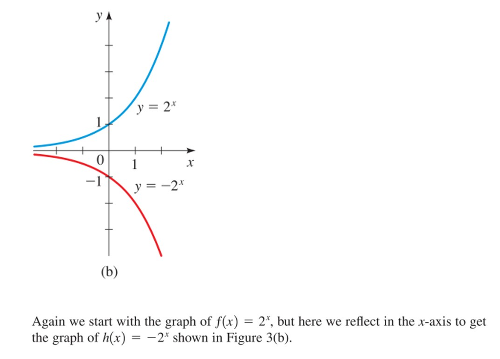

Figure 28: Reflection of $y=2^x$ across the horizontal axis to produce $y=-2^x$. Source: Stewart, Redlin, and Watson, *Precalculus: Mathematics for Calculus*, 6th ed.

Compare:

$$2^{-x}=\frac{1}{2^x}$$

with:

$$-2^x=-(2^x)$$

The first expression is **positive** and decreases toward zero as $x$ increases. The second is **negative** and reflects the graph of $2^x$ across the horizontal axis. These are not the same function. The graph $y=-2^x$ is **not** an appropriate model for the mass of radioactive material remaining because it produces negative outputs.

##### Why Are Inverse Functions Important?

So far, we have examined how mathematical functions describe relationships between inputs and outputs.

A function takes an input, performs a mathematical operation, and produces an output:

$$\boxed{\text{Input}\longrightarrow\text{Function}\longrightarrow\text{Output}}$$

But what if we already know the output and want to determine the original input?

This is where **inverse functions** become useful. An inverse function reverses the relationship described by the original function, allowing us to work backward from an output to its corresponding input:

$$\boxed{\text{Output}\longrightarrow\text{Inverse Function}\longrightarrow\text{Input}}$$

For example, consider the exponential function:

$$f(x)=2^x$$

If the input is $x=3$, we calculate:

$$f(3)=2^3=8$$

Now suppose the output is 8, but the input is unknown:

$$2^x=8$$

We want to know: **What exponent produces an output of 8 when the base is 2?**

The inverse of an exponential function is a logarithmic function. We can write:

$$\log_2(8)=x$$

Therefore:

$$\boxed{x=3}$$

The exponential function calculates an **output from a known input**. Its logarithmic inverse determines the **input from a known output**.

**NoteWhy Is This Useful?**

In hazardous materials chemistry, we may know the result of a physical process but need to determine what happened before that result was observed.

Consider radioactive decay:

- If we know the initial mass of a radioactive isotope, its half-life, and the elapsed time, an exponential model allows us to calculate the **remaining mass**.
- If we know the initial mass, its half-life, and the remaining mass, logarithms allow us to determine **how much time has elapsed**.

The difference is **which quantity is unknown**. When elapsed time appears in an exponent, a logarithm allows us to reverse the exponential relationship and solve for time.

**This is why we study inverse functions:** they allow us to work backward from a known result to the input that produced it.